# Intégration des données Indice invertébrés multimétrique (I2M2)

```r
knitr::opts_chunk$set(echo = TRUE)
library(config) # Utilisation d'un fichier de configuration, cf  https://db.rstudio.com/best-practices/managing-credentials/#stored-in-a-file-with-config
library(tidyverse)
library(DBI) # pour les connexions aux BDD
library(RPostgres) # driver postgres
library(RMariaDB) # driver
library(RMySQL)
library(lubridate) # calcul sur les dates
library(mice) # Gestion des données manquantes
library(httr) #
library(jsonlite)
library(plotly) # Graphiques interactifs
library(leaflet) # Cartes interactives

#------------------------
#  FONCTIONS
#------------------------

db.insertion <- function(con,table,data) {

  mise_a_jour <- paste0(format.Date(Sys.Date(),"%d/%m/%Y"), " : Actualisation ",params$actualisation)

  if(dbExistsTable(con,table)){

  # Date de la dernière donnée en base
  Date_max <- tbl(con, table) %>% summarise(Date_max = max(Date, na.rm = TRUE)) %>% pull(Date_max)
  if(is.na(Date_max)) Date_max <- as.Date(paste0(params$actualisation,"-01-01"),"%Y-%m-%d")-1

  # Données plus récentes à insérer
  data <- data %>% filter(as.Date(Date,'%d/%m/%Y') > Date_max && year(as.Date(Date,'%d/%m/%Y')) < as.integer(params$actualisation)+1)

  # Existe-t-il des données à insérer ?
if (isTRUE(data %>% tally() > 0)) {

  # Insertion des nouvelles lignes
  dbWriteTable(con, table, data, overwrite=FALSE, append=TRUE,
                             encoding = "latin1")

  # Horodate en commentaire
dbGetQuery(con, paste0("ALTER TABLE ",table," COMMENT = '",mise_a_jour,"';"))

paste0("Données insérées : ",data%>%tally)

}
  else {

    paste0("Aucune donnée à insérer depuis le ", format.Date(Date_max,"%d/%m/%Y"))

    } # fin if(données à insérer)

  } # fin if (table existe)

  else { # La table n'existe pas

    # Création de la table
  dbWriteTable(con, table, data, overwrite=TRUE, append=FALSE,
                             encoding = "latin1")

    dbGetQuery(con, paste0("ALTER TABLE ",table," COMMENT = '",mise_a_jour,"';"))
  } # fin if(table n'existe pas)

} # fin db.insertion
```

```r
#
# conf <- config::get("mysql_oeb")
#
# con_oeb_calcul_i2m2 <- dbConnect(odbc::odbc(),
#                              Driver=conf$driver,
#                              host = conf$server,
#                              UID = conf$uid,
#                              PWD = conf$pwd,
#                              database = "eau_calcul_i2m2",
#                              encoding = "latin1")

conf <- config::get("mysql_oeb")

con_eau_calcul_i2m2 <- dbConnect(RMariaDB::MariaDB(), default.file = '../../.my.cnf', groups="mysql_oeb",
dbname = "eau_calcul_i2m2")

con_referentiels <- dbConnect(RMariaDB::MariaDB(), default.file = '../../.my.cnf', groups="mysql_oeb",
dbname = "eau_referentiels")

conf <- config::get("postgres_dev")

con_postgresql_dev <- DBI::dbConnect(odbc::odbc(),
                          Driver       = conf$driver,
                          servername   = conf$server,
                          UID = conf$uid,
                          PWD = conf$pwd,
                          Port = conf$port,
                          database = conf$database,
                             encoding = "latin1")
```

# Outil d’évaluation I2M

## Source

> Mondy CP, Villeneuve B, Archaimbault V, Usseglio-Polatera P. (2012) A new macroinvertebrate-based multimetric index (I2M2) to evaluate ecological quality of French wadeable streams fulfilling the WFD demands: A taxonomical and trait approach. Ecological indicators, 18: 452-67

> Usseglio-Polatera, P. & Mondy, C. (2011) Développement et optimisation de l’indice biologique macroinvertébrés benthiques (I2M2) pour les cours d’eau. Partenariat Onema / UPV-Metz - LIEBE - UMR-CNRS 7146, 27p.

## Champs en entrée

- CODE_OPERATION Code de l’opération de contrôle désignée. Le champ est obligatoire et de type alphanumérique.
- CODE_STATION Code de la station associée à l’opération. Le champ est facultatif.
- DATE Date à laquelle l’opération a été effectuée. Le champ est facultatif.
- TYPO_NATIONALE Selon la nomenclature sandre 408. Mnémonique de l’élément de la typologie nationale auquel est rattachée la station. Le champ est obligatoire.
- CODE_PHASE Selon la nomenclature 480. Le champ est obligatoire. Seuls les codes de l’élément de la nomenclature sont acceptés.
- CODE_TAXON Code sandre du taxon identifié. Le champ est obligatoire et de type entier numérique positif.
- RESULTAT Effectif ou présence du taxon identifié. Le champ est obligatoire et de type entier numérique positif.
- CODE_REMARQUE Selon la nomenclature sandre 155. Le champ est obligatoire. Seules les modalités 1 ou 4 sont acceptées

## Champs en sortie

- CODE_OPERATION Code de l’opération de contrôle renseigné. Ce champ est repris du fichier d’entrée.
- CODE_STATION Code de la station associée à l’opération. Ce champ est repris du fichier d’entrée.
- DATE Date à laquelle l’opération a été effectuée. Ce champ est repris du fichier d’entrée.
- CODE_PAR Code sandre du paramètre de sortie.
- LIB_PAR Libellé du paramètre de sortie.
- RESULTAT Valeur du paramètre de sortie en EQR.
- COMMENTAIRES Information sur les taxons non contributifs (liste taxonomique et proportion du prélèvement).

# Outil de diagnostic ODInvertebre

Notice : ODInvertebres_v1.0.2_Format_echange.pdf

## Champs du fichier d’entrée

- CODE_OPERATION Code de l’opération de contrôle désignée. Le champ est obligatoire et de type alphanumérique.
- CODE_STATION Code de la station associée à l’opération. Le champ est facultatif.
- DATE Date à laquelle l’opération a été effectuée. Le champ est facultatif.
- TYPO_NATIONALE Selon la nomenclature sandre 408. Code de typologie nationale auquel est rattachée la station. Le champ est facultatif
- CODE_PHASE Selon la nomenclature 480. Le champ est facultatif.
- CODE_TAXON Code sandre du taxon identifié. Le champ est obligatoire et de type entier numérique positif.
- RESULTAT Effectif ou présence du taxon identifié. Le champ est obligatoire et de type entier numérique positif.
- CODE_REMARQUE Selon la nomenclature sandre 155. Le champ est obligatoire et seules les modalités 1 ou 4 sont acceptées.

## Champs du fichier de sortie

- CODE_STATION Code de la station associée à l’opération. Ce champ est repris du fichier d’entrée.
- DATE Date à laquelle l’opération a été effectuée. Ce champs est repris du fichier d’entrée.
- CODE_OPERATION Code de l’opération de contrôle renseigné. Ce champ est repris du fichier d’entrée.
- MATIERES_ORGANIQUES Probabilité d’impact par les matières organiques et oxydables. Cette pression est estimée en utilisant les paramètres individuels décrits dans les grilles du SEQ-eau v2: oxygène dissous, taux de saturation en oxygène, demande biochimique en oxygène (DBO5), demande chimique en oxygène (DCO), carbone organique dissous, ammonium et azote Kjeldahl.
- MATIERES_PHOSPHOREES Probabilité d’impact par les matières phosphorées. Cette pression est estimée en utilisant les paramètres individuels décrits dans les grilles du SEQ-eau v2: orthophosphates et phosphore total.
- MATIERES_AZOTEES Probabilité d’impact par les matières azotées (hors nitrates). Cette pression est estimée en utilisant les paramètres individuels décrits dans les grilles du SEQ-eau v2: ammonium, azote Kjeldahl et nitrites.
- NITRATES Probabilité d’impact par les nitrates
- HAP Probabilité d’impact par les hydrocarbures aromatiques polycycliques. Cette pression est estimée en utilisant les 16 HAP individuels décrits dans les grilles du SEQ-eau v2
- PESTICIDES Probabilité d’impact par les pesticides. Cette pression est estimée en utilisant les 74 pesticides individuels décrits dans les grilles du SEQ-eau v2.
- RIPISYLVE Probabilité d’impact liée à la dégradation de la ripisylve. Cette pression est estimée par le taux de couverture forestière dans la zone de 30m de part et d’autre du lit mineur.
- VOIES_COMMUNICATION Probabilité d’impact liée à la présence de voies de communication dans le lit mineur.
- URBANISATION_100M Probabilité d’impact liée à l’urbanisation dans une zone de 100m de part et d’autre du cours d’eau.
- RISQUE_COLMATAGE Probabilité d’impact liée au colmatage des substrat. Cette pression est estimée par le risque potentiel d’érosion des sols.
- INSTABILITE_HYDROLOGIQUE Probabilité d’impact liée à l’instabilité hydrologique. Cette pression est estimée en intégrant les rapports surface agricole irriguée/surface totale du bassin versant et volume d’eau retenu/volume d’eau qui s’écoule. ANTHROPISATION_BV Probabilité d’impact liée à l’anthropisation globale du bassin versant. Cette pression est estimée en intégrant les pourcentages d’urbanisation, d’agriculture intensive et de surfaces naturelles à l’échelle du bassin versant.

# Import des fichiers de sortie SEEE

- Utiliser le [site du Système d’évaluation de l’état des eaux (SEEE)](https://seee.eaufrance.fr/) pour traiter les fichiers d’entrée
- Sauvegarder les fichiers de sortie dans les dossiers
  - O:\01.BD_EAU2M2_seee_i2m2 (pour l’outil d’évaluation)
  - et O:\01.BD_EAU2M2_seee_outildiag (pour l’outil de diagnostic)

```r
# Lecture et union des fichiers de sortie SEEE

# Fichiers de sortie SEE / outil d'évaluation
import_i2m2 <- list.files(paste0(params$chemin_source,"\\Traitement\\sortie_seee_i2m2"), pattern=paste0("Sortie_SEEE_I2M2_", params$actualisation)) %>%
    map_df(~read.csv(paste0(params$chemin_source,"\\Traitement\\sortie_seee_i2m2\\",.), skip = 1, sep=';', colClasses=c("CODE_OPERATION"="character")))

# Fichiers de sortie SEE / outil de diagnostic
import_i2m2_outildiag <- list.files(paste0(params$chemin_source,"\\Traitement\\sortie_seee_outildiag"), pattern=paste0("Sortie_SEEE_ODInvertebres_", params$actualisation)) %>%
    map_df(~read.csv(paste0(params$chemin_source,"\\Traitement\\sortie_seee_outildiag\\",.), skip = 1, sep=';', colClasses=c("CODE_OPERATION"="character")))
```

# Import des référentiels

- Référentiel des sites depuis la base MariaDB OEB / eau_referentiels.eau_referentiel_site
- Référentiel des codes de séries dans le dossier source (TODO à intégrer en base)

```r
referentiel_sites <- tbl(con_referentiels, "eau_referentiel_site")%>%
  select(LbSite,CdSite,Coord_X_wgs84,Coord_Y_wgs84)

referentiel_series <- read.csv(paste0(params$chemin_source,"\\ref_series.csv"), sep=';', encoding = "UTF-8")
```

# Table des indices i2m2

```r
data_i2m2 <- import_i2m2 %>%
  mutate(CdSite = sprintf("%08d", CODE_STATION),
         Serie = paste(CODE_PAR,LIB_PAR,sep=" - "),
         Resultat = as.numeric(RESULTAT),
         Date = as.Date(DATE,'%d/%m/%Y')) %>%
  left_join(referentiel_sites, by="CdSite", copy=TRUE)%>%
  select(
  Code_entite_geographique = CdSite,
  Lible_entite_geographique = LbSite,
  CoordX_WGS84 = Coord_X_wgs84,
  CoordY_WGS84 = Coord_Y_wgs84,
  Date,
  Serie,
  Resultat)

data_i2m2 %>%
  summarise("Lignes" = n(),
            "Sites" = n_distinct(Code_entite_geographique),
            "Site connus" = n_distinct(Lible_entite_geographique),
            "Site inconnus" = n_distinct(Code_entite_geographique)-n_distinct(Lible_entite_geographique),
            "Dates non renseignées" = sum(is.na(Date)),
            "Date min" = min(Date, na.rm=TRUE),
            "Date max" = max(Date, na.rm=TRUE),
            "Series" = n_distinct(Serie),
            "Serie non renseignée" = sum(is.na(Serie)))
```

| Lignes | Sites | Site connus | Site inconnus | Dates non renseignées | Date min | Date max | Series | Serie non renseignée |
| --- | --- | --- | --- | --- | --- | --- | --- | --- |
| 1078 | 154 | 143 | 11 | 0 | 2020-05-28 | 2020-10-14 | 7 | 0 |

## Intégrité des données

```
     Code_entite_geographique Date Serie Resultat Lible_entite_geographique CoordX_WGS84 CoordY_WGS84
1001                        1    1     1        1                         1            1            1   0
77                          1    1     1        1                         0            0            0   3
                            0    0     0        0                        77           77           77 231
```

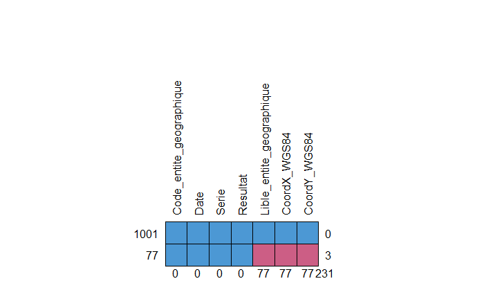

```r
# Package mice pour représenter les données manquantes dans le jeu de données
  mice::md.pattern(data_i2m2, rotate.names=T)
```

```r
# 2020 : 77 lignes sans site connu
# 2019 : 7 dates non renseignées
```

### Codes des sites inconnus

```r
sites_inconnus <- data_i2m2  %>%
  anti_join(referentiel_sites, by=c("Code_entite_geographique" = "CdSite"), copy=TRUE) %>%
  distinct(Code_entite_geographique)

sites_inconnus
```

| Code_entite_geographique |
| --- |
| 04110700 |
| 04115540 |
| 04115580 |
| 04115675 |
| 04116400 |
| 04123100 |
| 04123400 |
| 04123495 |
| 04123710 |
| 04123760 |

[output cut: 1 more lines]

## Visualisation des données

### Histogramme des indices I2M2

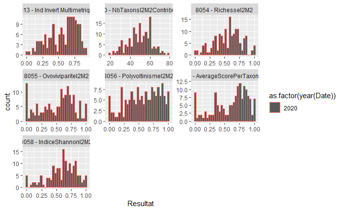

```r
data_i2m2 %>%
  ggplot(aes(x=Resultat, color=as.factor(year(Date))))+
  geom_histogram()+
  facet_wrap(~Serie, scales = "free")
```

### Carte leaflet

```r
data_i2m2 %>%
  filter(Serie == "7613 - Ind Invert Multimetrique")%>%
leaflet() %>%
  addTiles() %>%
  addCircleMarkers(~CoordX_WGS84,
                   ~CoordY_WGS84,
                   #color=~as.factor(Resultat>0.5),
                   radius = 1,
                   opacity = 1,
                   label=~Lible_entite_geographique,
                   popup=~Code_entite_geographique)
```

```
Data contains 11 rows with either missing or invalid lat/lon values and will be ignored
```

[interactive chart not shown]

```r
# Table au format de la BD MYSQL LOCAL

oeb_i2m2 <- data_i2m2 %>%
  filter(!is.na(Lible_entite_geographique)) %>% # Retirer les sites absents du référentiel
  mutate(Resultat = as.character(Resultat),
         Date = format.Date(Date,'%d/%m/%Y')) %>%
  select(
  Code_entite_geographique,
  Lible_entite_geographique,
  CoordX_WGS84,
  CoordY_WGS84,
  Date,
  Serie,
  Resultat)
```